# Soccer Power Index Analysis

Data Vizualization Project 2022/2023

Matteo Fiore - 17140

## Introduction

The aim of the project is to visualize the correlation between SPI and the results of football matches played during the last 5 years.

The Soccer Power Index (SPI) is a metric used to rank the level of competitiveness of a Soccer Team. The index has been designed by [ESPN](https://www.espn.com/world-cup/story/_/id/4447078/ce/us/guide-espn-spi-ratings) and it tries to be as objective as possible, by trying to depict which team is the most likely to have success.

In particular I will focus on two teams, one from the Serie A and one from the Premier League. To understand the differences between the index predictions and the actual results in different seasons, for different teams in different countries.

```r
libraries <- c(
  "tidyverse",
  "gapminder",
  "gridExtra",
  "tidyr",
  "tibble"
)
load_libs <- function(libraries) {
  # Use a snapshot of the package repository, for reproducibility purposes
  MRAN <- "https://cran.microsoft.com/snapshot/2022-09-15/"
  req <- unlist(lapply(libraries, require, character.only = TRUE))
  need <- libraries[req == FALSE]
  if (length(need) > 0) {
    install.packages(need, repos=MRAN)
    lapply(need, require, character.only = TRUE)
  }
}
load_libs(libraries)
```

## Data retrieval

First we download the csv file that contains all the matches played in the major leagues around the world the past five years. The data comes from this [source](https://projects.fivethirtyeight.com/soccer-api/club/spi_matches.csv).

```r
#load data set
spi_matches_url <- "https://projects.fivethirtyeight.com/soccer-api/club/spi_matches.csv"

spi_matches <- read_csv(spi_matches_url, na=c("", " "))
spi_matches
```

```
## # A tibble: 65,977 × 23
##    season date       league…¹ league team1 team2  spi1  spi2 prob1 prob2 probtie
##     <dbl> <date>        <dbl> <chr>  <chr> <chr> <dbl> <dbl> <dbl> <dbl>   <dbl>
##  1   2016 2016-07-09     7921 FA Wo… Live… Read…  51.6  50.4 0.439 0.277   0.284
##  2   2016 2016-07-10     7921 FA Wo… Arse… Nott…  46.6  54.0 0.357 0.361   0.282
##  3   2016 2016-07-10     7921 FA Wo… Chel… Birm…  59.8  54.6 0.480 0.249   0.271
##  4   2016 2016-07-16     7921 FA Wo… Live… Nott…  53    52.4 0.429 0.270   0.301
##  5   2016 2016-07-17     7921 FA Wo… Chel… Arse…  59.4  61.0 0.412 0.316   0.272
##  6   2016 2016-07-24     7921 FA Wo… Read… Birm…  50.8  55.0 0.382 0.32    0.298
##  7   2016 2016-07-24     7921 FA Wo… Nott… Manc…  48.1  60.2 0.308 0.389   0.303
##  8   2016 2016-07-31     7921 FA Wo… Read… Nott…  50.6  52.6 0.407 0.303   0.290
##  9   2016 2016-07-31     7921 FA Wo… Arse… Live…  48.3  48.5 0.435 0.31    0.255
## 10   2016 2016-08-03     7921 FA Wo… Read… Manc…  50.4  63.2 0.306 0.420   0.274
## # … with 65,967 more rows, 12 more variables: proj_score1 <dbl>,
## #   proj_score2 <dbl>, importance1 <dbl>, importance2 <dbl>, score1 <dbl>,
## #   score2 <dbl>, xg1 <dbl>, xg2 <dbl>, nsxg1 <dbl>, nsxg2 <dbl>,
## #   adj_score1 <dbl>, adj_score2 <dbl>, and abbreviated variable name
## #   ¹league_id
```

### Data exploration

The dataframe contains the following columns:

```r
names(spi_matches)
```

```
##  [1] "season"      "date"        "league_id"   "league"      "team1"
##  [6] "team2"       "spi1"        "spi2"        "prob1"       "prob2"
## [11] "probtie"     "proj_score1" "proj_score2" "importance1" "importance2"
## [16] "score1"      "score2"      "xg1"         "xg2"         "nsxg1"
## [21] "nsxg2"       "adj_score1"  "adj_score2"
```

It has the following dimension:

```r
dim(spi_matches)
```

```
## [1] 65977    23
```

And it contains a lot of NA values:

```r
sum(is.na(spi_matches))
```

```
## [1] 226012
```

As we can see, the dataframe has a substantial size. Therefore, it will be essential to properly analyse its structure and add/remove the information that are not needed for this research project.

## Data preparation

In this step, I am going to prepare the data before proceeding with the visualization part.

I will start by removing the NA values:

```r
spi_matches_without_na <- spi_matches %>%
  drop_na()
spi_matches_without_na
```

```
## # A tibble: 30,922 × 23
##    season date       league_id league      team1 team2  spi1  spi2  prob1  prob2
##     <dbl> <date>         <dbl> <chr>       <chr> <chr> <dbl> <dbl>  <dbl>  <dbl>
##  1   2016 2016-08-12      1843 French Lig… Bast… Pari…  51.2  85.7 0.0463 0.838
##  2   2016 2016-08-12      1843 French Lig… AS M… Guin…  68.8  56.5 0.571  0.167
##  3   2016 2016-08-13      2411 Barclays P… Hull… Leic…  53.6  66.8 0.346  0.362
##  4   2016 2016-08-13      2411 Barclays P… Burn… Swan…  59.0  59.7 0.448  0.266
##  5   2016 2016-08-13      2411 Barclays P… Sout… Watf…  69.5  59.3 0.576  0.187
##  6   2016 2016-08-13      2411 Barclays P… Crys… West…  55.2  58.7 0.421  0.294
##  7   2016 2016-08-13      2411 Barclays P… Ever… Tott…  68.0  73.2 0.391  0.340
##  8   2016 2016-08-13      2411 Barclays P… Midd… Stok…  56.3  60.4 0.438  0.269
##  9   2016 2016-08-13      1843 French Lig… Bord… St E…  62.0  64.9 0.423  0.276
## 10   2016 2016-08-13      2411 Barclays P… Manc… Sund…  86.4  53.6 0.815  0.0525
## # … with 30,912 more rows, and 13 more variables: probtie <dbl>,
## #   proj_score1 <dbl>, proj_score2 <dbl>, importance1 <dbl>, importance2 <dbl>,
## #   score1 <dbl>, score2 <dbl>, xg1 <dbl>, xg2 <dbl>, nsxg1 <dbl>, nsxg2 <dbl>,
## #   adj_score1 <dbl>, adj_score2 <dbl>
```

I am going to remove some columns that are not necessary for this research project. Since we are analyzing past matches, it is not necessary for us to have the columns related to the probabilities, importance, projected and adjusted score or xgs; as we have already the SPI that includes this information. This information will be removed because they are already captured in other columns and for this reason, I want to avoid duplicate information.

```r
columns_to_remove = c("prob1","prob2","probtie","proj_score1", "proj_score2", "importance1", "importance2", "adj_score1","adj_score2","xg1","xg2","nsxg1","nsxg2")
spi_matches_cleaned <- subset(spi_matches_without_na, select = !(names(spi_matches_without_na) %in% columns_to_remove))
spi_matches_cleaned
```

```
## # A tibble: 30,922 × 10
##    season date       league_id league      team1 team2  spi1  spi2 score1 score2
##     <dbl> <date>         <dbl> <chr>       <chr> <chr> <dbl> <dbl>  <dbl>  <dbl>
##  1   2016 2016-08-12      1843 French Lig… Bast… Pari…  51.2  85.7      0      1
##  2   2016 2016-08-12      1843 French Lig… AS M… Guin…  68.8  56.5      2      2
##  3   2016 2016-08-13      2411 Barclays P… Hull… Leic…  53.6  66.8      2      1
##  4   2016 2016-08-13      2411 Barclays P… Burn… Swan…  59.0  59.7      0      1
##  5   2016 2016-08-13      2411 Barclays P… Sout… Watf…  69.5  59.3      1      1
##  6   2016 2016-08-13      2411 Barclays P… Crys… West…  55.2  58.7      0      1
##  7   2016 2016-08-13      2411 Barclays P… Ever… Tott…  68.0  73.2      1      1
##  8   2016 2016-08-13      2411 Barclays P… Midd… Stok…  56.3  60.4      1      1
##  9   2016 2016-08-13      1843 French Lig… Bord… St E…  62.0  64.9      3      2
## 10   2016 2016-08-13      2411 Barclays P… Manc… Sund…  86.4  53.6      2      1
## # … with 30,912 more rows
```

After removing the unwanted columns, we need to add the columns representing the outcome of the matches. The outcome can result in a team obtaining 3 points if it wins, 1 if it draws and 0 if the team loses. The added results will be added as two new additional columns, these columns will indicate the obtaining points of the home team and the away team.

```r
spi_matches_with_results<-spi_matches_cleaned%>%
mutate(points_home =  case_when(score1>score2 ~ 3,
                            score1<score2 ~ 0,
                            TRUE ~ 1)) %>%
mutate(points_away =  case_when(score1>score2 ~ 0,
                            score1<score2 ~ 3,
                            TRUE ~ 1))
spi_matches_with_results
```

```
## # A tibble: 30,922 × 12
##    season date       league_id league      team1 team2  spi1  spi2 score1 score2
##     <dbl> <date>         <dbl> <chr>       <chr> <chr> <dbl> <dbl>  <dbl>  <dbl>
##  1   2016 2016-08-12      1843 French Lig… Bast… Pari…  51.2  85.7      0      1
##  2   2016 2016-08-12      1843 French Lig… AS M… Guin…  68.8  56.5      2      2
##  3   2016 2016-08-13      2411 Barclays P… Hull… Leic…  53.6  66.8      2      1
##  4   2016 2016-08-13      2411 Barclays P… Burn… Swan…  59.0  59.7      0      1
##  5   2016 2016-08-13      2411 Barclays P… Sout… Watf…  69.5  59.3      1      1
##  6   2016 2016-08-13      2411 Barclays P… Crys… West…  55.2  58.7      0      1
##  7   2016 2016-08-13      2411 Barclays P… Ever… Tott…  68.0  73.2      1      1
##  8   2016 2016-08-13      2411 Barclays P… Midd… Stok…  56.3  60.4      1      1
##  9   2016 2016-08-13      1843 French Lig… Bord… St E…  62.0  64.9      3      2
## 10   2016 2016-08-13      2411 Barclays P… Manc… Sund…  86.4  53.6      2      1
## # … with 30,912 more rows, and 2 more variables: points_home <dbl>,
## #   points_away <dbl>
```

## Data Vizualization

Since we want to analyse one team from Serie A and Premier League, we want to compute their average SPI across the years. The teams we are going to consider are AS Roma(Serie A, Italy) and Liverpool(Premier League, UK).

### AS Roma analysis

Firstly,I will select all the matches played in the Italy Serie A by Roma until the 2021 season. Therefore, it is essential to filter all the matches Roma and add other information to the dataframe such as if Roma played at home or away, the points made by Roma in each match, the sum of the points made each match that will be used to analyse the performances over the years and the match number of that season.

```r
#all matches with a column that specify if Roma played at home or away
serie_a_matches_Roma <- spi_matches_with_results%>%
  filter(league_id == 1854, season<=2021, team1 == "AS Roma" | team2 == "AS Roma")%>%
  mutate(location = ifelse(team1 == "AS Roma", "home", "away")) %>%
  mutate(roma_points = ifelse(location == "home", points_home, points_away)) %>%
  group_by(season) %>%
  mutate(match_week = row_number())

serie_a_matches_Roma
```

```
## # A tibble: 224 × 15
## # Groups:   season [6]
##    season date       league_id league      team1 team2  spi1  spi2 score1 score2
##     <dbl> <date>         <dbl> <chr>       <chr> <chr> <dbl> <dbl>  <dbl>  <dbl>
##  1   2016 2016-08-20      1854 Italy Seri… AS R… Udin…  74.6  55.6      4      0
##  2   2016 2016-08-28      1854 Italy Seri… Cagl… AS R…  56.8  76.5      2      2
##  3   2016 2016-09-11      1854 Italy Seri… AS R… Samp…  76.1  55.9      3      2
##  4   2016 2016-09-18      1854 Italy Seri… Fior… AS R…  68.6  76.0      1      0
##  5   2016 2016-09-25      1854 Italy Seri… Tori… AS R…  63.8  76.1      3      1
##  6   2016 2016-10-02      1854 Italy Seri… AS R… Inte…  75.5  72.4      2      1
##  7   2016 2016-10-15      1854 Italy Seri… Napo… AS R…  77.2  75.6      1      3
##  8   2016 2016-10-23      1854 Italy Seri… AS R… Pale…  76.4  46.9      4      1
##  9   2016 2016-10-30      1854 Italy Seri… Empo… AS R…  46.8  77.8      0      0
## 10   2016 2016-11-06      1854 Italy Seri… AS R… Bolo…  78.0  52.4      3      0
## # … with 214 more rows, and 5 more variables: points_home <dbl>,
## #   points_away <dbl>, location <chr>, roma_points <dbl>, match_week <int>
```

After preparing the dataframe, we analyse the performances of Roma throughout the seasons. First of all we want to see the trend of the average SPI index Roma had from the 2016 season until the 2021 season.

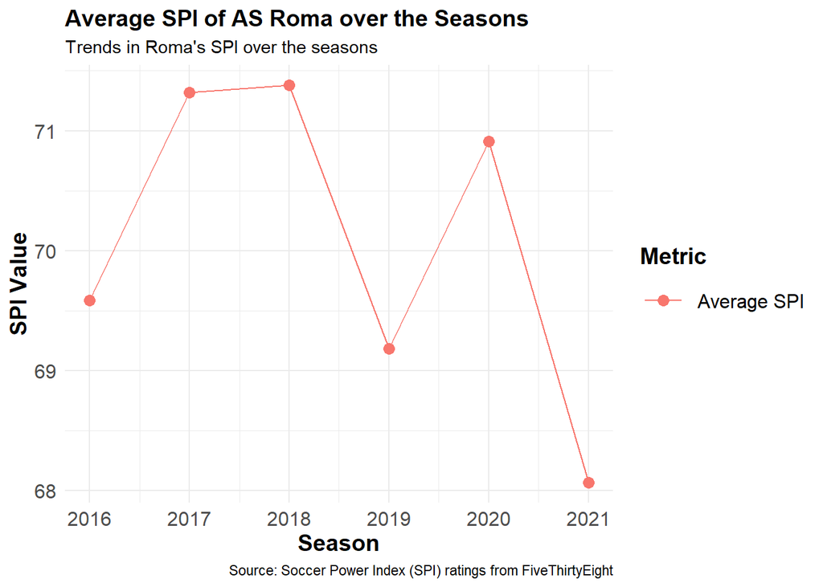

```r
avg_spi_roma <- serie_a_matches_Roma %>%
  filter(team1 == 'AS Roma' | team2 == 'AS Roma')%>%
  group_by(season)%>%
  summarize(average_spi = mean(c(spi1,spi2)))%>%
  ggplot(mapping = aes(x = season)) +
  geom_line(mapping =aes(y = average_spi, color = "Average SPI")) +
  geom_point(mapping =aes(y = average_spi, color = "Average SPI"), size=3) +
  guides(fill = guide_legend(title = "Metric", reverse = TRUE))+
  labs(x = "Season", y = "SPI Value", title = "Average SPI of AS Roma over the Seasons", subtitle = "Trends in Roma's SPI over the seasons",caption = "Source: Soccer Power Index (SPI) ratings from FiveThirtyEight") +
  guides(color = guide_legend(title = "Metric", reverse = TRUE))+
  theme_minimal() +
  theme(plot.title = element_text(size = 14, family = "sans", face = "bold"),
        axis.text = element_text(size = 12, family = "sans"),
        axis.title = element_text(size = 14, family = "sans", face = "bold"),
        legend.key.height = unit(1, "cm"),
        legend.key.width = unit(1, "cm"),
        legend.title = element_text(size = 14, family = "sans", face = "bold"),
        legend.text = element_text(size = 12, family = "sans"),
        )

avg_spi_roma
```

As shown in the graph, we can see that AS Roma had an SPI value ranging from 69 to 71 from season 2016 until 2020 season. Nevertheless, there has been a major decreasing of the average value of the SPI in 2021.

#### What happened in 2021?

We start by analysing the trend of the points made by Roma during the 2021/2022 season.

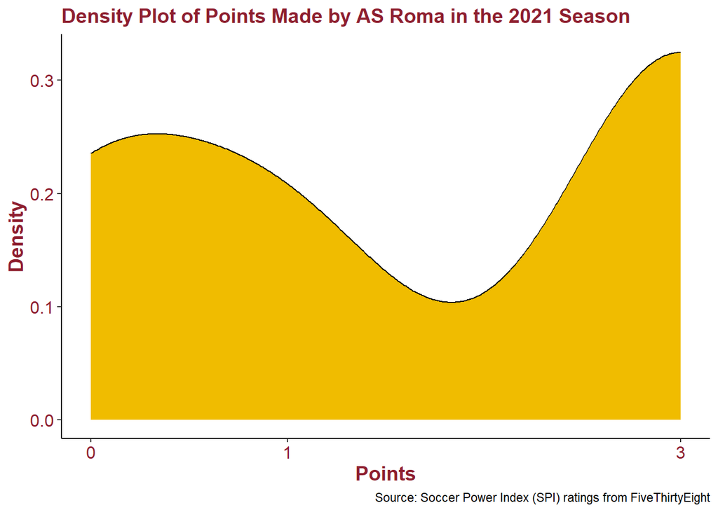

```r
roma_points_2021_density <- serie_a_matches_Roma %>%
  filter(season == 2021, (team1 == "AS Roma" | team2 == "AS Roma")) %>%
  group_by(match_week) %>%
  summarize(points = sum(roma_points)) %>%
  ggplot( aes(x = points)) +
  geom_density(color = "black", fill ="#F0BC00" ) +
  scale_x_continuous(breaks = c(0, 1, 3), limits = c(0, 3), name = "Points") +
  labs(title = "Density Plot of Points Made by AS Roma in the 2021 Season",
       x = "Points", y = "Density", caption = "Source: Soccer Power Index (SPI) ratings from FiveThirtyEight")+
  theme_classic() +
  theme(
    plot.background = element_rect(fill = "white"),
    axis.text = element_text(color = "#8E1F2F", size = 12, family = "sans"),
    plot.title =  element_text(color = "#8E1F2F", size = 14, family = "sans", face = "bold"),
    axis.title =  element_text(color = "#8E1F2F", size = 14, family = "sans", face = "bold"),
    legend.key.height = unit(1, "cm"),
    legend.key.width = unit(1, "cm"),
    legend.title = element_text(size = 14, family = "sans", face = "bold"),
    legend.text = element_text(size = 12, family = "sans")
    )
roma_points_2021_density
```

Overall, the distribution of points seems pretty balanced. Therefore, we can have a deeper look to the distribution of points gained by AS Roma.

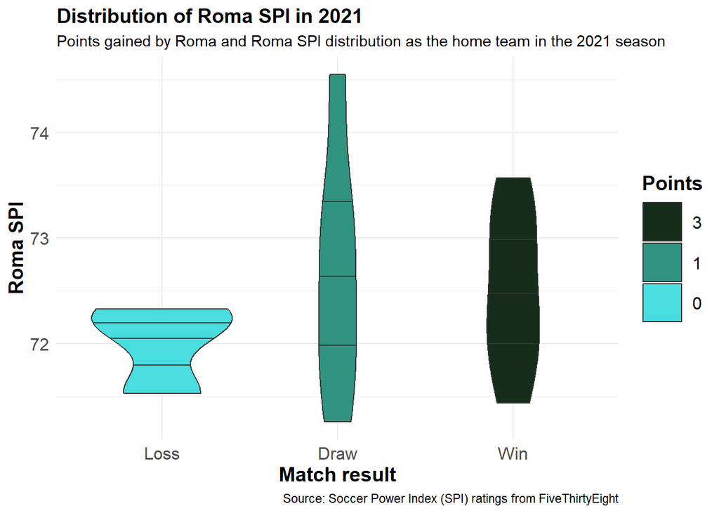

```r
roma_distribution_home <- serie_a_matches_Roma %>%
  filter(season == 2021, team1 == "AS Roma") %>%
  mutate(roma_points = factor(roma_points , levels = c("0", "1", "3"))) %>%
ggplot(aes(x = roma_points, y = spi1, fill = roma_points)) +
  geom_violin(scale = "area", draw_quantiles = c(0.25, 0.5, 0.75), width = 0.8) +
  scale_fill_manual(values=c("#4ADDE0","#30937F","#152D1A")) +
  scale_x_discrete(labels = c("0" = "Loss", "1" = "Draw", "3" = "Win")) +
  guides(fill = guide_legend(reverse = TRUE, title = "Points"))+
  labs(title = "Distribution of Roma SPI in 2021", subtitle = "Points gained by Roma and Roma SPI distribution as the home team in the 2021 season", caption = "Source: Soccer Power Index (SPI) ratings from FiveThirtyEight", x = "Match result", y = "Roma SPI") +
    theme_minimal() +
  theme(plot.title = element_text(size = 14, family = "sans", face = "bold"),
        axis.text = element_text(size = 12, family = "sans"),
        axis.title = element_text(size = 14, family = "sans", face = "bold"),
        legend.key.height = unit(1, "cm"),
        legend.key.width = unit(1, "cm"),
        legend.title = element_text(size = 14, family = "sans", face = "bold"),
        legend.text = element_text(size = 12, family = "sans"),
        )



roma_distribution_home
```

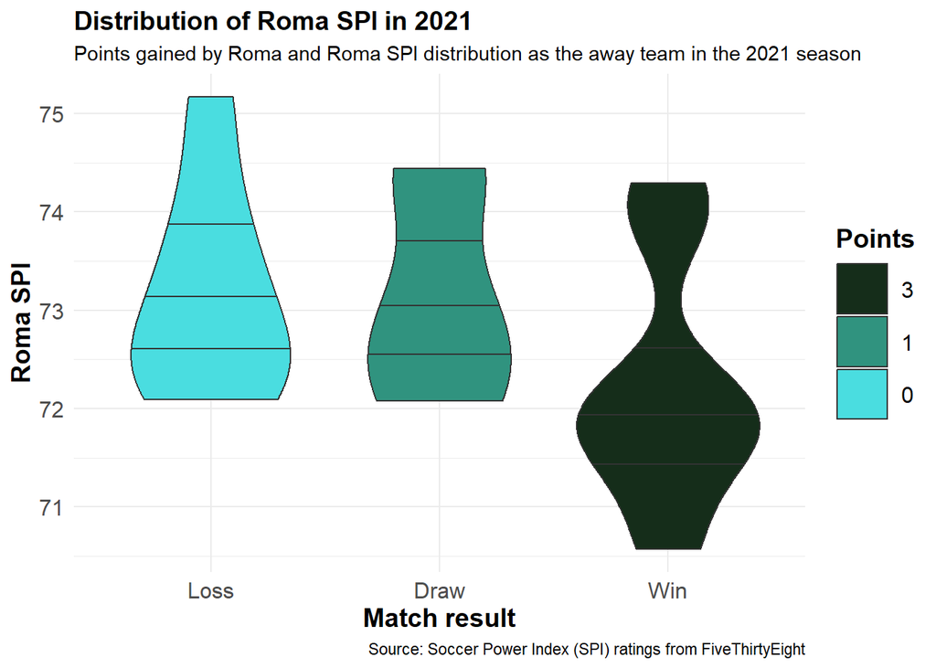

```r
roma_distribution_away <- serie_a_matches_Roma %>%
  filter(season == 2021, team2 == "AS Roma") %>%
  mutate(roma_points = factor(roma_points , levels = c("0", "1", "3"))) %>%
ggplot(aes(x = roma_points, y = spi2, fill = roma_points)) +
  geom_violin(scale = "area", draw_quantiles = c(0.25, 0.5, 0.75), width = 0.8) +
  scale_fill_manual(values=c("#4ADDE0","#30937F","#152D1A")) +
  scale_x_discrete(labels = c("0" = "Loss", "1" = "Draw", "3" = "Win")) +
  guides(fill = guide_legend(reverse = TRUE, title ="Points"))+
  labs(title = "Distribution of Roma SPI in 2021", subtitle = "Points gained by Roma and Roma SPI distribution as the away team in the 2021 season", caption = "Source: Soccer Power Index (SPI) ratings from FiveThirtyEight", x = "Match result", y = "Roma SPI") +
    theme_minimal() +
  theme(plot.title = element_text(size = 14, family = "sans", face = "bold"),
        axis.text = element_text(size = 12, family = "sans"),
        axis.title = element_text(size = 14, family = "sans", face = "bold"),
        legend.key.height = unit(1, "cm"),
        legend.key.width = unit(1, "cm"),
        legend.title = element_text(size = 14, family = "sans", face = "bold"),
        legend.text = element_text(size = 12, family = "sans"),
        )



roma_distribution_away
```

We are interested to see Roma performances and the changes of its SPI value throughout the season. Therefore, we check how it performed while playing as the home team and as the away team. By doing this analysis, we can have a more thorough overview of the validity of the SPI of Roma, compared with Roma’s performances (i.e. points gained).

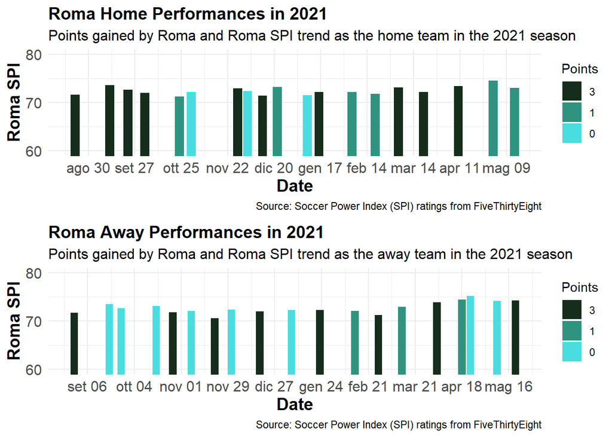

```r
#home
Roma_2021_home <- serie_a_matches_Roma %>%
  filter(season==2021, team1 =='AS Roma') %>%
  mutate(points_home = factor(points_home, levels = c("3", "1", "0"))) %>%
  ggplot(position = "dodge")+
  geom_col(mapping = aes(x = date, y = spi1, fill = points_home))+
  scale_x_date(date_breaks = "4 week", date_labels = "%b %d", name = "Date") +
  scale_fill_manual(values=c("#152D1A","#30937F","#4ADDE0") )+
  labs(title = "Roma Home Performances in 2021", subtitle = "Points gained by Roma and Roma SPI trend as the home team in the 2021 season", caption = "Source: Soccer Power Index (SPI) ratings from FiveThirtyEight", x = "Date", y = "Roma SPI") +
  coord_cartesian(ylim = c(60,80)) +
  scale_y_continuous(breaks = seq(60, 80, 10)) +
  theme_minimal() +
  theme(plot.title = element_text(size = 14, family = "sans", face = "bold"),
        plot.subtitle = element_text(size = 12, family = "sans"),
        axis.text = element_text(size = 12, family = "sans"),
        axis.title = element_text(size = 14, family = "sans", face = "bold")) +
  guides(fill = guide_legend(title = "Points"))

#away
Roma_2021_away <- serie_a_matches_Roma %>%
  filter(season == 2021, team2 =='AS Roma') %>%
  mutate(points_away = factor(points_away, levels = c("3", "1", "0"))) %>%
  ggplot(mapping = aes(x = date, y = spi2, fill = points_away)) +
  geom_col(position = "dodge") +
  scale_x_date(date_breaks = "4 week", date_labels = "%b %d", name = "Date") +
  scale_fill_manual(values=c("#152D1A","#30937F","#4ADDE0") )+
  labs(title = "Roma Away Performances in 2021", subtitle = "Points gained by Roma and Roma SPI trend as the away team in the 2021 season", caption = "Source: Soccer Power Index (SPI) ratings from FiveThirtyEight", x = "Date", y = "Roma SPI") +
  coord_cartesian(ylim = c(60,80)) +
  scale_y_continuous(breaks = seq(60, 80, 10)) +
  theme_minimal() +
  theme(plot.title = element_text(size = 14, family = "sans", face = "bold"),
        plot.subtitle = element_text(size = 12, family = "sans"),
        axis.text = element_text(size = 12, family = "sans"),
        axis.title = element_text(size = 14, family = "sans", face = "bold")
        ) +
  guides(fill = guide_legend(title = "Points"))

#comparison
grid.arrange(Roma_2021_home, Roma_2021_away, nrow = 2)
```

By comparing the two plots, we can see that AS Roma had bad performances while playing as the away team, while the performances as the home team where satisfactory, just 3 losses in 19 matches.

To have an understanding of how Roma permormed, we need to understand also the SPI value of the opponent, to have a better view of the accuracy of the index.

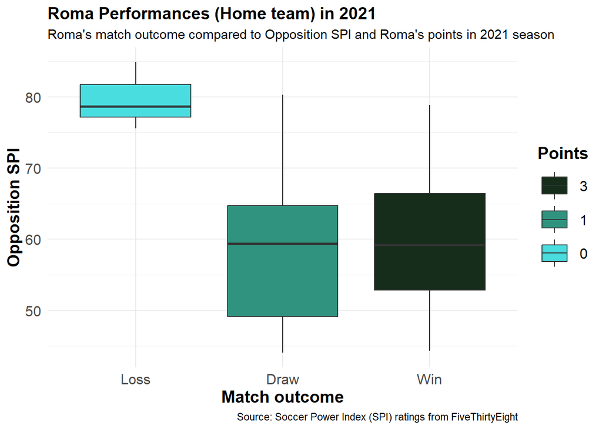

```r
points_roma_ho = serie_a_matches_Roma %>%
  filter(season==2021, team1 =='AS Roma') %>%
  mutate(roma_points = factor(roma_points , levels = c("0", "1", "3"))) %>%
ggplot(aes(x = factor(roma_points), y = spi2, fill=roma_points)) +
  scale_fill_manual(values=c("#4ADDE0","#30937F","#152D1A"))+
  geom_boxplot() +
  scale_x_discrete(labels = c("0" = "Loss", "1" = "Draw", "3" = "Win")) +
  theme_minimal() +
  theme(plot.title = element_text(size = 14, family = "sans", face = "bold"),
        axis.text = element_text(size = 12, family = "sans"),
        axis.title = element_text(size = 14, family = "sans", face = "bold"),
        legend.key.height = unit(1, "cm"),
        legend.key.width = unit(1, "cm"),
        legend.title = element_text(size = 14, family = "sans", face = "bold"),
        legend.text = element_text(size = 12, family = "sans"),
        ) +
  guides(fill = guide_legend(reverse = TRUE, title = "Points"))+
  labs(title = "Roma Performances (Home team) in 2021", subtitle = "Roma's match outcome compared to Opposition SPI and Roma's points in 2021 season", x="Match outcome",y="Opposition SPI", caption = "Source: Soccer Power Index (SPI) ratings from FiveThirtyEight")


points_roma_ho
```

Roma performed decently as the home team. They lost games against team with an high SPI value, and draw some matches against team with team with low SPI. Let’s check the away performances of Roma.

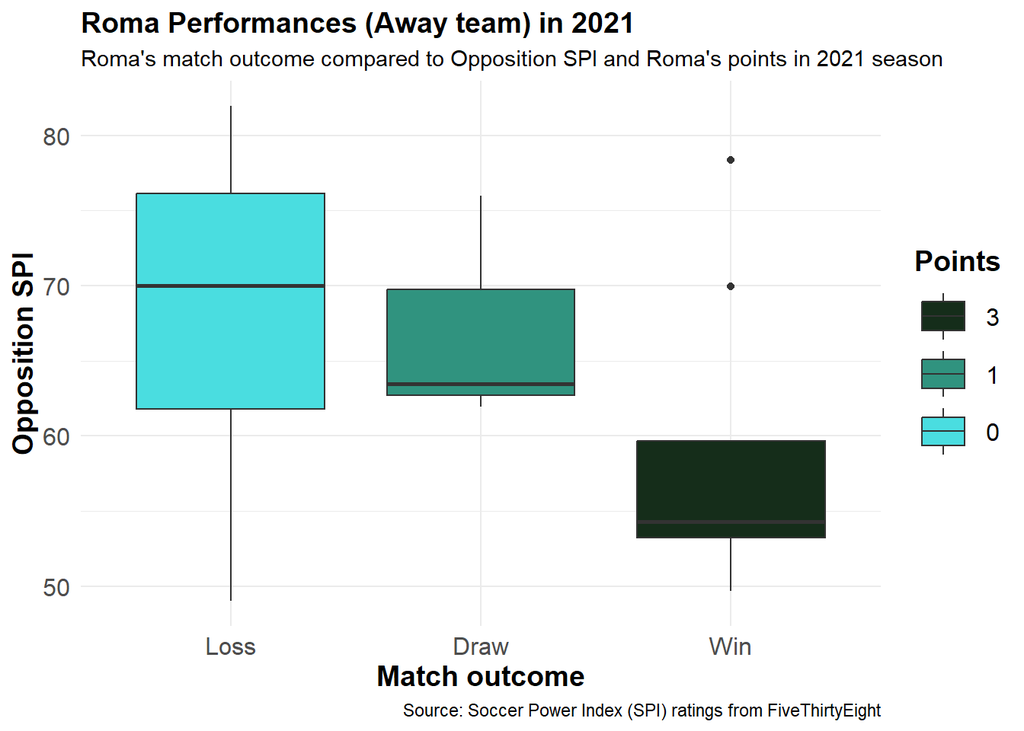

```r
points_roma_aw = serie_a_matches_Roma %>%
  filter(season==2021, team2 =='AS Roma') %>%
  mutate(roma_points = factor(roma_points , levels = c("0", "1", "3"))) %>%
  ggplot(aes(x = factor(roma_points), y = spi1, fill=roma_points)) +
  scale_fill_manual(values=c("#4ADDE0","#30937F","#152D1A"))+
  geom_boxplot() +
  scale_x_discrete(labels = c("0" = "Loss", "1" = "Draw", "3" = "Win")) +
  theme_minimal() +
  theme(plot.title = element_text(size = 14, family = "sans", face = "bold"),
        axis.text = element_text(size = 12, family = "sans"),
        axis.title = element_text(size = 14, family = "sans", face = "bold"),
        legend.key.height = unit(1, "cm"),
        legend.key.width = unit(1, "cm"),
        legend.title = element_text(size = 14, family = "sans", face = "bold"),
        legend.text = element_text(size = 12, family = "sans")
        ) +
  guides(fill = guide_legend(reverse = TRUE, title ="Points"))+
  labs(title = "Roma Performances (Away team) in 2021", subtitle = "Roma's match outcome compared to Opposition SPI and Roma's points in 2021 season", x="Match outcome",y="Opposition SPI", caption = "Source: Soccer Power Index (SPI) ratings from FiveThirtyEight")

points_roma_aw
```

Overall, Roma struggled to gain point against opponent with an high SPI.

Now, we will compare the results of Roma with the SPI of the opposition team, to check in which matches Roma struggled the most.

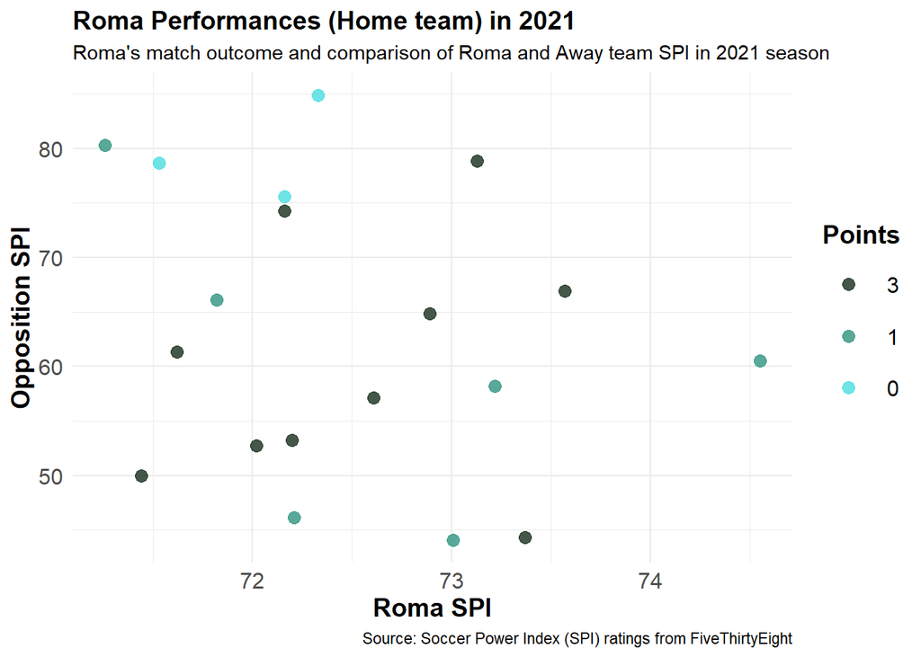

```r
points_roma_h = serie_a_matches_Roma %>%
  filter(season==2021, team1 =='AS Roma') %>%
  mutate(roma_points = factor(roma_points , levels = c("3", "1", "0"))) %>%
  ggplot(aes(x = spi1, y = spi2, color = roma_points)) +
  geom_point(size = 3, alpha = 0.8) +
  scale_color_manual(values=c("#152D1A","#30937F","#4ADDE0"))+
  theme_minimal() +
  theme(plot.title = element_text(size = 14, family = "sans", face = "bold"),
        axis.text = element_text(size = 12, family = "sans"),
        axis.title = element_text(size = 14, family = "sans", face = "bold"),
        legend.key.height = unit(1, "cm"),
        legend.key.width = unit(1, "cm"),
        legend.title = element_text(size = 14, family = "sans", face = "bold"),
        legend.text = element_text(size = 12, family = "sans")
        ) +
  guides(color = guide_legend(title = "Points")) +
  labs(title = "Roma Performances (Home team) in 2021", subtitle = "Roma's match outcome and comparison of Roma and Away team SPI in 2021 season", caption = "Source: Soccer Power Index (SPI) ratings from FiveThirtyEight", x= "Roma SPI", y ="Opposition SPI")


points_roma_h
```

What happened when Roma was the away team?

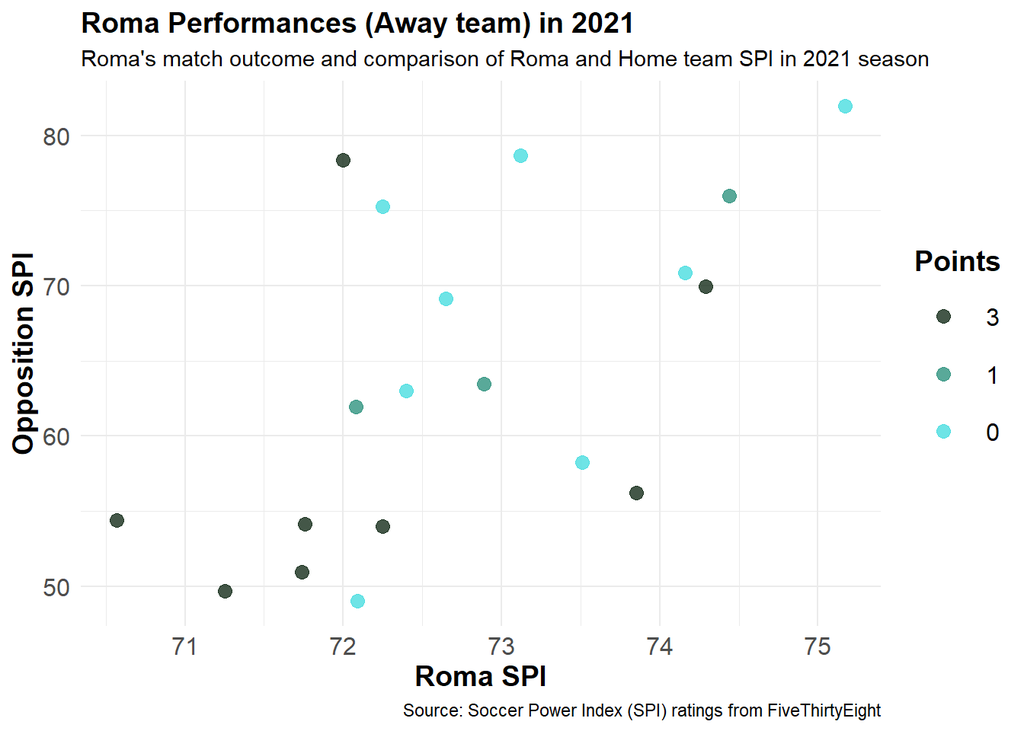

```r
points_roma_a = serie_a_matches_Roma %>%
  filter(season==2021, team2 =='AS Roma') %>%
  mutate(roma_points = factor(roma_points , levels = c("3", "1", "0"))) %>%
  ggplot(aes(x = spi2, y = spi1, color = roma_points)) +
  geom_point(size = 3, alpha = 0.8) +
  scale_color_manual(values=c("#152D1A","#30937F","#4ADDE0"))+
  theme_minimal() +
  theme(plot.title = element_text(size = 14, family = "sans", face = "bold"),
        axis.text = element_text(size = 12, family = "sans"),
        axis.title = element_text(size = 14, family = "sans", face = "bold"),
        legend.key.height = unit(1, "cm"),
        legend.key.width = unit(1, "cm"),
        legend.title = element_text(size = 14, family = "sans", face = "bold"),
        legend.text = element_text(size = 12, family = "sans")
        ) +
  guides(color = guide_legend(title = "Points")) +
  labs(title = "Roma Performances (Away team) in 2021", subtitle = "Roma's match outcome and comparison of Roma and Home team SPI in 2021 season", caption = "Source: Soccer Power Index (SPI) ratings from FiveThirtyEight", x = "Roma SPI", y="Opposition SPI")


points_roma_a
```

From this plot, we can confirm that Roma had very bad performances while playing away from its own stadium. In particular, they struggled a lot against opponents with an high SPI value. The majority of the points gained by Roma were done against teams with a lower SPI value.

To summarize, Roma was able to gain more points while playing as the home team. Nevertheless, the struggling they had throughout the season against opponents with an higher SPI values is one of the main cause of their bad performance in the 2021 season that lead them to finish 6th in the table. The SPI, however, failed to understand why Roma lost numerous points against teams with a much lower SPI.

## Liverpool analysis

Now, we want to analyse another team from another league, to see if the SPI has been accurate or not.

```r
spi_premierleague<- spi_matches_with_results%>%
  filter(league_id == 2411, season<=2021, team1 == "Liverpool" | team2 == "Liverpool")%>%
  mutate(location = ifelse(team1 == "Liverpool", "home", "away")) %>%
  mutate(liverpool_points = ifelse(location == "home", points_home, points_away)) %>%
  group_by(season) %>%
  mutate(match_week = row_number())

spi_premierleague
```

```
## # A tibble: 225 × 15
## # Groups:   season [6]
##    season date       league_id league      team1 team2  spi1  spi2 score1 score2
##     <dbl> <date>         <dbl> <chr>       <chr> <chr> <dbl> <dbl>  <dbl>  <dbl>
##  1   2016 2016-08-14      2411 Barclays P… Arse… Live…  82.6  77.4      3      4
##  2   2016 2016-08-20      2411 Barclays P… Burn… Live…  57.8  78.9      2      0
##  3   2016 2016-08-27      2411 Barclays P… Tott… Live…  73.7  78.1      1      1
##  4   2016 2016-09-10      2411 Barclays P… Live… Leic…  78.4  67.1      4      1
##  5   2016 2016-09-16      2411 Barclays P… Chel… Live…  81.7  79.3      1      2
##  6   2016 2016-09-24      2411 Barclays P… Live… Hull…  79.9  52.3      5      1
##  7   2016 2016-10-01      2411 Barclays P… Swan… Live…  58.6  81.6      1      2
##  8   2016 2016-10-17      2411 Barclays P… Live… Manc…  81.6  80.7      0      0
##  9   2016 2016-10-22      2411 Barclays P… Live… West…  81.3  59.2      2      1
## 10   2016 2016-10-29      2411 Barclays P… Crys… Live…  59.4  80.9      2      4
## # … with 215 more rows, and 5 more variables: points_home <dbl>,
## #   points_away <dbl>, location <chr>, liverpool_points <dbl>, match_week <int>
```

After filtering the data to match our interest, we start by plotting the performances of Liverpool throughout the seasons. First of all we want to see the trend of the average SPI index Liverpool had from the 2016 season until the 2021 season.

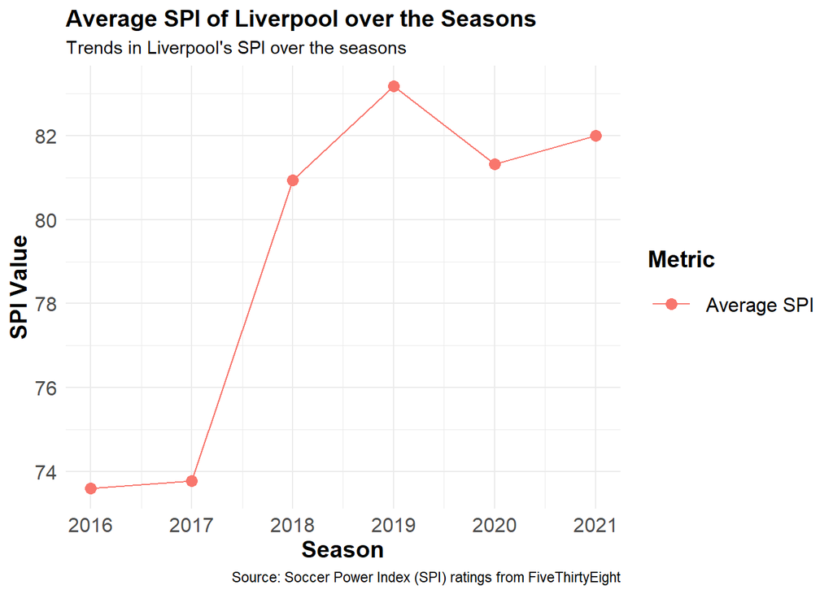

```r
avg_spi_liverpool <- spi_premierleague %>%
  filter(team1 == 'Liverpool' | team2 == 'Liverpool')%>%
  group_by(season)%>%
  summarize(average_spi = mean(c(spi1,spi2)))%>%
  ggplot(mapping = aes(x = season)) +
  geom_line(mapping =aes(y = average_spi, color = "Average SPI")) +
  geom_point(mapping =aes(y = average_spi, color = "Average SPI"), size=3) +
  guides(fill = guide_legend(title = "Metric", reverse = TRUE))+
  labs(x = "Season", y = "SPI Value", title = "Average SPI of Liverpool over the Seasons", subtitle = "Trends in Liverpool's SPI over the seasons",caption = "Source: Soccer Power Index (SPI) ratings from FiveThirtyEight") +
  guides(color = guide_legend(title = "Metric", reverse = TRUE))+
  theme_minimal() +
  theme(plot.title = element_text(size = 14, family = "sans", face = "bold"),
        axis.text = element_text(size = 12, family = "sans"),
        axis.title = element_text(size = 14, family = "sans", face = "bold"),
        legend.key.height = unit(1, "cm"),
        legend.key.width = unit(1, "cm"),
        legend.title = element_text(size = 14, family = "sans", face = "bold"),
        legend.text = element_text(size = 12, family = "sans"),
        )

avg_spi_liverpool
```

From this plot, we can see that Liverpool’s SPI had a huge increase: they had an SPI of around 74 in 2016 and 2017, but they were able to increase it in 2018, with a value of over 80. This value has been maintained also in 2019, 2020 and 2021.

#### What happened in 2018?

We start analysing the trend of Liverpool in the 2018 season.

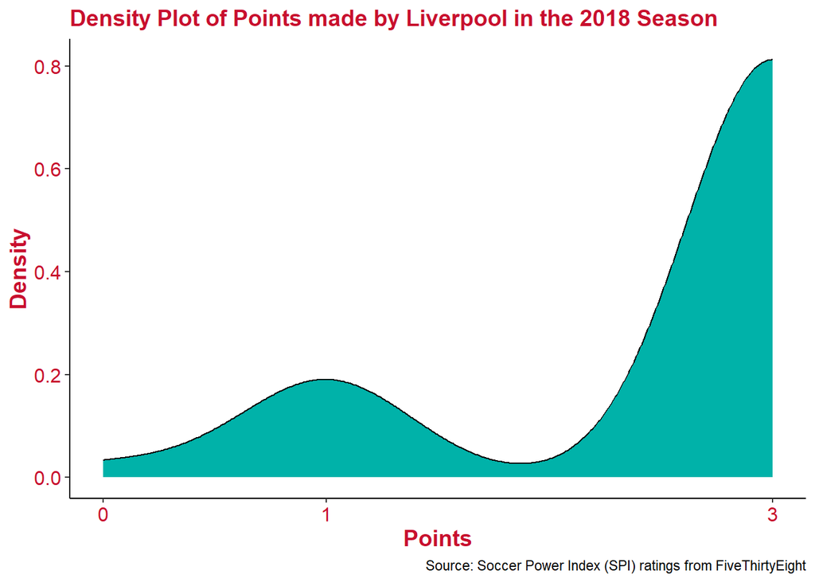

```r
liverpool_points_2018_density <- spi_premierleague %>%
  filter(season == 2018, (team1 == "Liverpool" | team2 == "Liverpool")) %>%
  group_by(match_week) %>%
  summarize(points = sum(liverpool_points)) %>%
  ggplot(aes(x = points)) +
  geom_density(color = "black", fill ="#00B2A9" ) +
  scale_x_continuous(breaks = c(0, 1, 3), limits = c(0, 3), name = "Points") +
  labs(title = "Density Plot of Points made by Liverpool in the 2018 Season",
       x = "Points", y = "Density", caption = "Source: Soccer Power Index (SPI) ratings from FiveThirtyEight")+
  theme_classic() +
  theme(
    plot.background = element_rect(fill = "white"),
    axis.text = element_text(color = "#C8102E", size = 12, family = "sans"),
    plot.title =  element_text(color = "#C8102E", size = 14, family = "sans", face = "bold"),
    axis.title =  element_text(color = "#C8102E", size = 14, family = "sans", face = "bold"),
    legend.key.height = unit(1, "cm"),
    legend.key.width = unit(1, "cm"),
    legend.title = element_text(size = 14, family = "sans", face = "bold"),
    legend.text = element_text(size = 12, family = "sans")
    )
liverpool_points_2018_density
```

The density shows that there has been an incredible amount of wins. Therefore, it is in the interest in our interest to analyse the Liverpool’s performances more into details.

[figure not shown]

```r
liverpool_distribution_home <- spi_premierleague %>%
   filter(season==2018, team1 =='Liverpool') %>%
  mutate(points_home = factor(points_home, levels = c("3", "1", "0"))) %>%
  ggplot(position = "dodge")+
  geom_col(mapping = aes(x = date, y = spi1, fill = points_home))+
  scale_x_date(date_breaks = "4 week", date_labels = "%b %d", name = "Date") +
  scale_fill_manual(values=c("#152D1A","#30937F","#4ADDE0") )+
  labs(title = "Liverpool Home Performances in 2018", subtitle = "Points gained by Liverpool and Liverpool SPI as the home team in the 2018 season", caption = "Source: Soccer Power Index (SPI) ratings from FiveThirtyEight", x = "Date", y = "Liverpool SPI") +
  coord_cartesian(ylim = c(80,100)) +
  scale_y_continuous(breaks = seq(80, 100, 10)) +
  theme_minimal() +
  theme(plot.title = element_text(size = 14, family = "sans", face = "bold"),
        plot.subtitle = element_text(size = 12, family = "sans"),
        axis.text = element_text(size = 12, family = "sans"),
        axis.title = element_text(size = 14, family = "sans", face = "bold")) +
  guides(fill = guide_legend(title = "Points"))

liverpool_distribution_away <- spi_premierleague %>%
   filter(season==2018, team2 =='Liverpool') %>%
  mutate(points_away = factor(points_away, levels = c("3", "1", "0"))) %>%
  ggplot(position = "dodge")+
  geom_col(mapping = aes(x = date, y = spi2, fill = points_away))+
  scale_x_date(date_breaks = "4 week", date_labels = "%b %d", name = "Date") +
  scale_fill_manual(values=c("#152D1A","#30937F","#4ADDE0") )+
  labs(title = "Liverpool Home Performances in 2018", subtitle = "Points gained by Liverpool and Liverpool SPI as the away team in the 2018 season", caption = "Source: Soccer Power Index (SPI) ratings from FiveThirtyEight", x = "Date", y = "Liverpool SPI") +
  coord_cartesian(ylim = c(80,100)) +
  scale_y_continuous(breaks = seq(80, 100, 10)) +
  theme_minimal() +
  theme(plot.title = element_text(size = 14, family = "sans", face = "bold"),
        plot.subtitle = element_text(size = 12, family = "sans"),
        axis.text = element_text(size = 12, family = "sans"),
        axis.title = element_text(size = 14, family = "sans", face = "bold")) +
  guides(fill = guide_legend(title = "Points"))

grid.arrange(liverpool_distribution_home, liverpool_distribution_away, nrow = 2)
```

The Liverpool’s performances while playing in its stadium were almost perfect, where they finished the season unbeaten, as they failed to win a match only twice.

On the other hand, Liverpool did lost a match while playing as the away team and collected also 5 draws.

Let’s analyse the SPI of the Liverpool’s opponent.

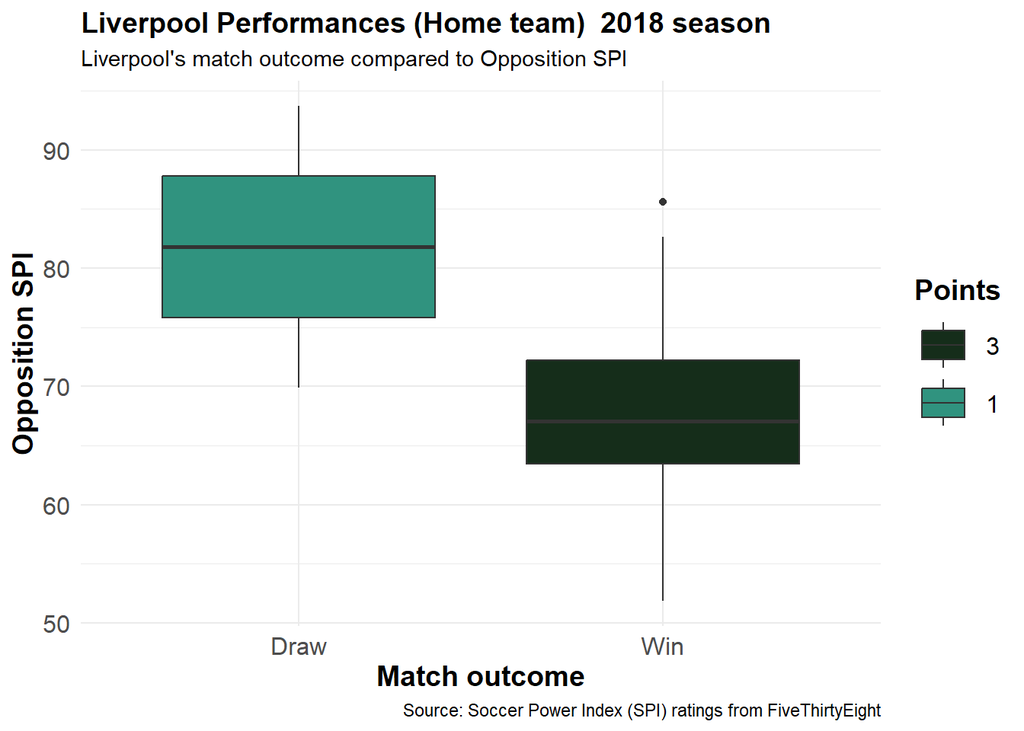

```r
points_lv_ho = spi_premierleague %>%
  filter(season==2018, team1 =='Liverpool') %>%
  mutate(liverpool_points = factor(liverpool_points , levels = c("0", "1", "3"))) %>%
ggplot(aes(x = factor(liverpool_points), y = spi2, fill=liverpool_points)) +
  scale_fill_manual(values=c("#30937F", "#152D1A"))+
  geom_boxplot() +
  scale_x_discrete(labels = c("0" = "Loss", "1" = "Draw", "3" = "Win")) +
  theme_minimal() +
  theme(plot.title = element_text(size = 14, family = "sans", face = "bold"),
        axis.text = element_text(size = 12, family = "sans"),
        axis.title = element_text(size = 14, family = "sans", face = "bold"),
        legend.key.height = unit(1, "cm"),
        legend.key.width = unit(1, "cm"),
        legend.title = element_text(size = 14, family = "sans", face = "bold"),
        legend.text = element_text(size = 12, family = "sans"),
        ) +
  guides(fill = guide_legend(reverse = TRUE, title = "Points"))+
 labs(title ="Liverpool Performances (Home team)  2018 season", subtitle = "Liverpool's match outcome compared to Opposition SPI" ,caption = "Source: Soccer Power Index (SPI) ratings from FiveThirtyEight", x="Match outcome",y="Opposition SPI")

points_lv_ho
```

Here, we can see that Liverpool failed to win against team with a very high SPI.

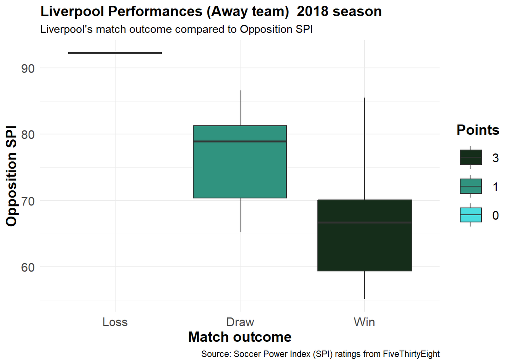

```r
points_lv_aw = spi_premierleague %>%
  filter(season==2018, team2 =='Liverpool') %>%
  mutate(liverpool_points = factor(liverpool_points , levels = c("0", "1", "3"))) %>%
  ggplot(aes(x = factor(liverpool_points), y = spi1, fill=liverpool_points)) +
  scale_fill_manual(values=c("#4ADDE0","#30937F","#152D1A"))+
  geom_boxplot() +
  scale_x_discrete(labels = c("0" = "Loss", "1" = "Draw", "3" = "Win")) +
  theme_minimal() +
  theme(plot.title = element_text(size = 14, family = "sans", face = "bold"),
        axis.text = element_text(size = 12, family = "sans"),
        axis.title = element_text(size = 14, family = "sans", face = "bold"),
        legend.key.height = unit(1, "cm"),
        legend.key.width = unit(1, "cm"),
        legend.title = element_text(size = 14, family = "sans", face = "bold"),
        legend.text = element_text(size = 12, family = "sans"),
        ) +
  guides(fill = guide_legend(reverse = TRUE, title = "Points"))+
  labs(title ="Liverpool Performances (Away team)  2018 season", subtitle = "Liverpool's match outcome compared to Opposition SPI" ,caption = "Source: Soccer Power Index (SPI) ratings from FiveThirtyEight", x="Match outcome",y="Opposition SPI")

points_lv_aw
```

Again we see that Liverpool struggled the most against teams with an higher SPI.

Was Liverpool the team with the highest SPI? We compare the SPI of the two teams and the match outcome, pointing out the final result.

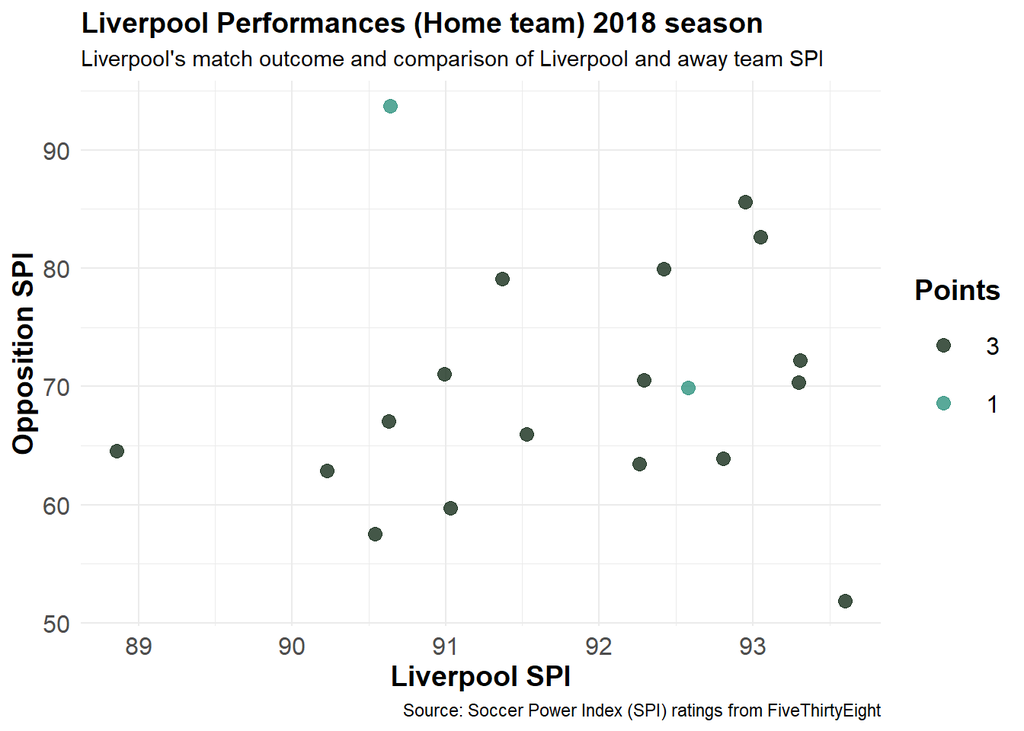

```r
points_lv_h = spi_premierleague %>%
  filter(season==2018, team1 =='Liverpool') %>%
  mutate(liverpool_points = factor(liverpool_points , levels = c("3", "1", "0"))) %>%
  ggplot(aes(x = spi1, y = spi2, color = liverpool_points)) +
  geom_point(size = 3, alpha = 0.8) +
  scale_color_manual(values=c("#152D1A","#30937F"))+
  theme_minimal() +
  theme(plot.title = element_text(size = 14, family = "sans", face = "bold"),
        axis.text = element_text(size = 12, family = "sans"),
        axis.title = element_text(size = 14, family = "sans", face = "bold"),
        legend.key.height = unit(1, "cm"),
        legend.key.width = unit(1, "cm"),
        legend.title = element_text(size = 14, family = "sans", face = "bold"),
        legend.text = element_text(size = 12, family = "sans")
        ) +
  guides(color = guide_legend(title = "Points")) +
  labs(title = "Liverpool Performances (Home team) 2018 season ", subtitle = "Liverpool's match outcome and comparison of Liverpool and away team SPI", caption = "Source: Soccer Power Index (SPI) ratings from FiveThirtyEight", x = "Liverpool SPI",y="Opposition SPI")


points_lv_h
```

Overall, while playing as the home team, Liverpool had an SPI higher than its opponents, except in one match where Liverpool and its opponent’ SPI was almost equal, thus indicating a balance matchup.

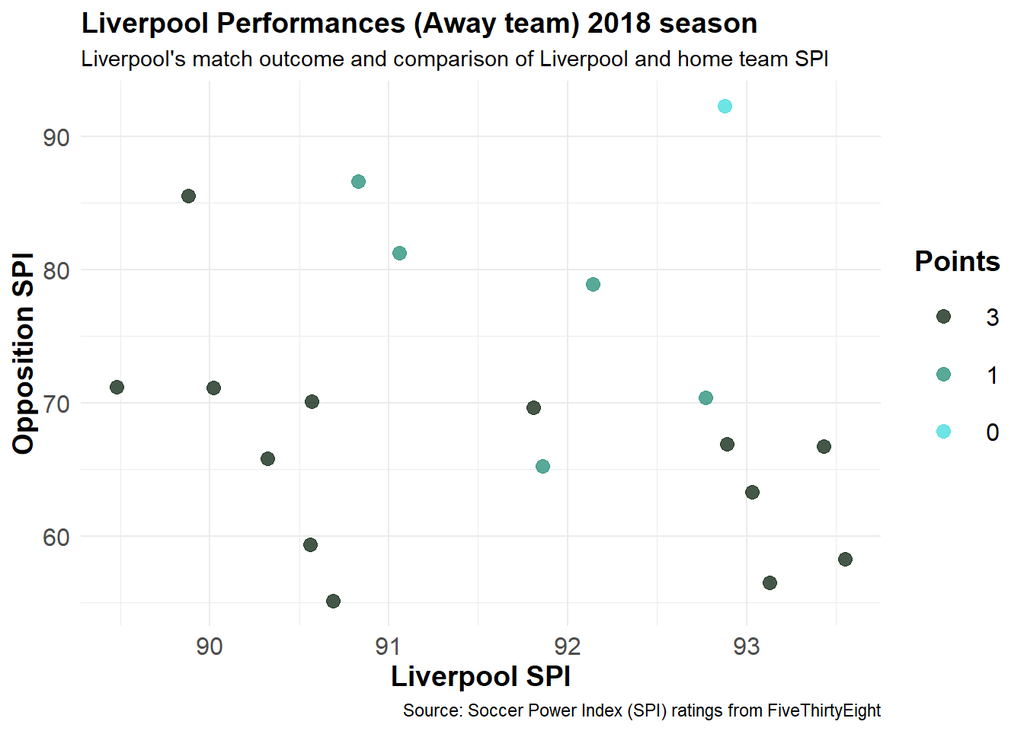

```r
points_lv_a = spi_premierleague %>%
  filter(season==2018, team2 =='Liverpool') %>%
  mutate(liverpool_points = factor(liverpool_points , levels = c("3", "1", "0"))) %>%
  ggplot(aes(x = spi2, y = spi1, color = liverpool_points)) +
  geom_point(size = 3, alpha = 0.8) +
  scale_color_manual(values=c("#152D1A","#30937F","#4ADDE0"))+
  theme_minimal() +
  theme(plot.title = element_text(size = 14, family = "sans", face = "bold"),
        axis.text = element_text(size = 12, family = "sans"),
        axis.title = element_text(size = 14, family = "sans", face = "bold"),
        legend.key.height = unit(1, "cm"),
        legend.key.width = unit(1, "cm"),
        legend.title = element_text(size = 14, family = "sans", face = "bold"),
        legend.text = element_text(size = 12, family = "sans")
        ) +
  guides(color = guide_legend(title = "Points")) +
  labs(title = "Liverpool Performances (Away team) 2018 season", subtitle = "Liverpool's match outcome and comparison of Liverpool and home team SPI", caption = "Source: Soccer Power Index (SPI) ratings from FiveThirtyEight", x = "Liverpool SPI",y = "Opposition SPI")


points_lv_a
```

Even though, Liverpool had the highest SPI, they struggled a lot while playing as the away team. In particular, they had two draws against teams that had SPI of 66 and 71 compared to Liverpool’s 91.8 and 92.7.

To conclude Liverpool’s 2018 analysis, we saw that they had the so called “home advantage” that helped them to stay undefeated while playing at home. They struggled more as the away team, but they still manage to obtain a fair amount of points.

## Conclusions

In this project we have explored some information about the SPI and the outcomes of football matches played in different years and countries by different teams. Overall, we found out that the dataset contains a lot of information about the validity of SPI and its ability to predict the winner’s team. Even if the SPI cannot fully predict the outcome of a match, we were able to see how it can be considered a good estimation.